# BSAN2204

Lecture 6

Exploratory Analysis

## Exploratory Analysis

Exploratory analysis refers to the process of summarising data in order to uncover patterns and relationships prior to formal modelling.

The aim of exploratory analysis to understand the available data and to develop some preliminary insights about key variables of interest in data.

We will work with a dataset built into `R` to demonstrate these methods in the lecture. The tutorial will apply these methods to the `MSD` for the Exploratory Analysis section of your *Predictive Analytics Report (A2)*.

## Descriptive statistics

Descriptive statistics form an important part of exploratory data analysis. For continuous (numeric) variables, these include measures of location (mean, median and mode), spread (standard deviation), and shape (skewness and kurtosis).

For categorical (factor) variables, these include measures of counts and proportions.

Statistics that relate to individual variables are called **univariate statistics**, whilst statistics that describe the joint distributions of two or more variables, they are called **bivariate** or **multivariate statistics**.

## Bi- and Multi- variate statistics

Beyond summarising data, tests for bivariate statistical significance often accompany descriptive statistics to support conclusions that patterns observed in the data are not due to random chance (i.e., they may potentially be explained).

Bivariate tests for differences in means between groups (e.g., t-test) or bivariate tests for associations in counts (e.g., chi‑square tests for contingency tables) both include tests for *statistically significance*.

Multivariate statistical analysis include tests for the associations among more than two variables. In the case of linear regression modelling (predictive analytics), multiple input variables are modelled as predictors of on a single output variable. Multivariate statistics are not typically reported as part of exploratory analysis.

## Statisical significance

Statistical significance refers to the likelihood of an observation to be due to random chance. The *lower* the probability of an event occurring statistically significant that event is.

We start with a *null hypothesis* (“nothing to see here”) and test how likely the data would be if that were true. If that probability (the **p‑value**) is very small (e.g., less than 0.05, or 5%), the result is *statistically significant* and lean toward not rejecting the *alternative hypothesis* (“something is different”).

It does not provide a proof, but it does reflect a confidence that the effect is real. Statistical significance does not indicate how large or important an effect is either.

## “Statistically speaking…”

In everyday use this phrase means there is statistical evidence for a pattern between two or more variables. What it *should imply* is that some significance tests have been conducted to support some claim. In reality, the speaker using “statistically speaking” may not have done these tests (or have the expertise to know if such tests have been done).

In business analytics contexts, as in daily conversation, use of the term “statistically speaking” should be used carefully!

*Statistically speaking*, people are more likely to make up statistics.

(Really?)

## Descriptive Statistics in `R`

`R` offers an analyst a wide range of of procedures for calculating descriptive statistics, including base `R` functions as well as a wide range of specialised non-base `R` packages which you can install from the CRAN.

The CRAN hosts many more `R` packages for descriptive statistics, but we will focus primarily on using `describe()` from the `psych` package. In your *Predictive Analytics Report (A2)*, it is recommended to use `psych::describe()` for no other reason than that it outputs objects of the class `data.frame` which are easy to `|>` to `kable()` for making nice tables in your R Markdown document.

You might discover other packages others on your own.

## Introduction to the `mtcars` data

The `mtcars` dataset is a classic built-in dataset in `R` containing performance and design specifications for 32 car models from the 1973-74 Motor Trend US magazine. It includes 11 numeric variables such as fuel efficiency, horsepower, weight, and transmission type.

The dataset is widely used in courses which teach `R`. You will commonly encounter this dataset in `R` documentation/help files which provide demonstrations of the use of various existing or newly released `R` packages.

To read more about the dataset, type `?mtcars` in the console window in R Studio.

## Demonstration: `summary()`

When `summary()` is applied to an `R` object which contains data, this command will output summary statistics. Recall its other use to summarise the contents of a `list` object (i.e., regression output).

For this demonstration, we will focus on the following variables from the `mtcars` data: miles per gallon (`mpg`), horsepower (`hp`), and weight (`wt`) by saving them to a character vector.

```r
myvars <- c("mpg", "hp", "wt")
```

## Output from `summary()`

The `summary()` function when applied to a data object provides the minimum, maximum, quartiles, and mean for quantitative/numerical (continuous) variables and frequencies for qualitative variables/factors (categorical variables).

```r
summary(mtcars[myvars])
```

```
      mpg              hp              wt
 Min.   :10.40   Min.   : 52.0   Min.   :1.513
 1st Qu.:15.43   1st Qu.: 96.5   1st Qu.:2.581
 Median :19.20   Median :123.0   Median :3.325
 Mean   :20.09   Mean   :146.7   Mean   :3.217
 3rd Qu.:22.80   3rd Qu.:180.0   3rd Qu.:3.610
 Max.   :33.90   Max.   :335.0   Max.   :5.424
```

## Notes on `R` syntax

`myvars` (a character vector containing the names of variables) is put in the column position in side square brackets `[]`. The following are equivalent but less efficient ways to get the same outputs:

```r
summary(mtcars[,c("mpg","hp","wt")])
```

```
      mpg              hp              wt
 Min.   :10.40   Min.   : 52.0   Min.   :1.513
 1st Qu.:15.43   1st Qu.: 96.5   1st Qu.:2.581
 Median :19.20   Median :123.0   Median :3.325
 Mean   :20.09   Mean   :146.7   Mean   :3.217
 3rd Qu.:22.80   3rd Qu.:180.0   3rd Qu.:3.610
 Max.   :33.90   Max.   :335.0   Max.   :5.424
```

```r
summary(mtcars$mpg)
```

```
   Min. 1st Qu.  Median    Mean 3rd Qu.    Max.
  10.40   15.43   19.20   20.09   22.80   33.90
```

```r
summary(mtcars$hp)
```

```
   Min. 1st Qu.  Median    Mean 3rd Qu.    Max.
   52.0    96.5   123.0   146.7   180.0   335.0
```

```r
summary(mtcars$wt)
```

```
   Min. 1st Qu.  Median    Mean 3rd Qu.    Max.
  1.513   2.581   3.325   3.217   3.610   5.424
```

## Features of `summary()`

`summary()` in is handy for a quick glance at your data, but it is deliberately minimal. For numeric variables, it outputs:

- Minimum value
- 1st Quartile (25th percentile)
- Median (50th percentile)
- Mean value
- 3rd Quartile (75th percentile)
- Maximum value

It does not show measures of the shape or spread of data (standard deviations, skewness or kurtosis). Further, it does not report the extent of any *missingness* in the data. For factors `summary()` shows counts of each level, and for characters it reports length and class.

## `psych` package: `describe()`

The `describe()` function from `psych` provides a richer set of descriptive statistics than including that covers all available measures of central tendency for numeric continuous data. This function is commonly applied in many contexts for more detailed exploratory analysis.

Using the variable list defined earlier:

```r
library(psych)
describe(mtcars[myvars])
```

```
    vars  n   mean    sd median trimmed   mad   min    max  range skew kurtosis
mpg    1 32  20.09  6.03  19.20   19.70  5.41 10.40  33.90  23.50 0.61    -0.37
hp     2 32 146.69 68.56 123.00  141.19 77.10 52.00 335.00 283.00 0.73    -0.14
wt     3 32   3.22  0.98   3.33    3.15  0.77  1.51   5.42   3.91 0.42    -0.02
       se
mpg  1.07
hp  12.12
wt   0.17
```

## Remember to install new packages

Are you seeing this error message?

`Error in library(xxxxx) : there is no package called ‘xxxxx’`

This means you do not have the package installed and available to load from your library. To install a package, use the GUI in R Studio or install from the console.

Note: do not include `install.packages()` within your `.Rmd` file!

(why not?)

## `describe()` generates a data frame

Recall the importance of paying attention to detail when it comes to ensuring the outputs in a report convey a high degree of professionalism. This requires a bit of work to get right!

A handy feature of `describe()` from `psych` is that its output is by default of the class data frame. This makes it ready to pipe to `kable()` which assumes a dataframe as its input.

```r
describe(mtcars[myvars]) |> kable()
```

|  | vars | n | mean | sd | median | trimmed | mad | min | max | range | skew | kurtosis | se |
| --- | --- | --- | --- | --- | --- | --- | --- | --- | --- | --- | --- | --- | --- |
| mpg | 1 | 32 | 20.09062 | 6.0269481 | 19.200 | 19.696154 | 5.4114900 | 10.400 | 33.900 | 23.500 | 0.6106550 | -0.3727660 | 1.0654240 |
| hp | 2 | 32 | 146.68750 | 68.5628685 | 123.000 | 141.192308 | 77.0952000 | 52.000 | 335.000 | 283.000 | 0.7260237 | -0.1355511 | 12.1203173 |
| wt | 3 | 32 | 3.21725 | 0.9784574 | 3.325 | 3.152692 | 0.7672455 | 1.513 | 5.424 | 3.911 | 0.4231465 | -0.0227108 | 0.1729685 |

## Piping using `|>`

`R`’s pipe operator `|>` is very useful. It takes the result of the expression on its left and passes (“pipes”) it as the first argument to the function on its right. It is a way to chain operations together without creating intermediate variables, making code more readable and expressive.

Using pipes improves the readability of `R` code by avoiding cluttering your source code with intermediate data processing steps.

The keyboard short cuts to insert `|>` are:

`ctrl shift M` (Windows)

`Cmd Shift M` (Mac)

You may need to configure R Studio to use |> instead of its predecessor %>%

## Carefully curating table contents

For continuous variables, we recommend only including measures of location (mean), spread (standard deviation), and shape (skewness and kurtosis). Saving the column names from the data frame that correspond to these statistics to a character vector will allow us to use this list across multiple tables.

```r
stats <- c("n", "mean", "sd", "skew", "kurtosis")
```

With a named list of variables and named list of statistics, we can pipe using `|>` the output of `describe()` to `kable()` to generate a report ready table formatted using R Markdown (instead of raw console output).

## `knitr` and `kable()` for descriptive stats

The `stats` character vector is used as the column reference within the square brackets `[]` for which `rows` and `colums` of the `describe()` output to render using `kable()` in R Markdown. The output of `describe()` is piped `round()` to restrict the values in the table to only report to 3 decimal places. We also add a table caption as an option within the `kable()` function.

```r
describe(mtcars[myvars])[, stats] |>
  round(3) |>
  kable(caption = "Descriptive Statistics for mpg, hp, and wt in mtcars")
```

Descriptive Statistics for mpg, hp, and wt in mtcars

|  | n | mean | sd | skew | kurtosis |
| --- | --- | --- | --- | --- | --- |
| mpg | 32 | 20.091 | 6.027 | 0.611 | -0.373 |
| hp | 32 | 146.688 | 68.563 | 0.726 | -0.136 |
| wt | 32 | 3.217 | 0.978 | 0.423 | -0.023 |

## Further formatting with `kableExtra`

The `kableExtra` package offers a wide range of functions to customise, style, and extend tables created with `kable()`. A very simple application is using `kable_styling()` to adjust the table font size. Check the `?kableExtra` help documentation for a full list of customisation options to explore on your own.

```r
library(kableExtra)

describe(mtcars[myvars])[, stats] |>
  round(3) |>
  kable(caption = "Descriptive Statistics for mpg, hp, and wt in mtcars") |>
  kable_styling(font_size = 14)
```

Descriptive Statistics for mpg, hp, and wt in mtcars

|  | n | mean | sd | skew | kurtosis |
| --- | --- | --- | --- | --- | --- |
| mpg | 32 | 20.091 | 6.027 | 0.611 | -0.373 |
| hp | 32 | 146.688 | 68.563 | 0.726 | -0.136 |
| wt | 32 | 3.217 | 0.978 | 0.423 | -0.023 |

## Descriptive statistics by group

When comparing groups of observations (rows of a dataset), the focus is usually on the descriptive statistics for each group rather than the total sample.

We can reuse the `stats` character vector of descriptive statistics we created earlier, so we do not need to think about how to curate what is included in the output.

We will compare the miles per gallon (`mpg`) of cars by their transmission type (`am`).

The variable `am` is a categorical variable in `mtcars` that groups observations (cars) by transmission type.

## Labelling factor variables

The categorical variables available in `mtcars` – `cyl` and `am` – are unlabelled so we will first label the levels of these factors.

Before working with categorical variables it is always important to check their labels, and if they are not labelled, to label them appropriately.

```r
mtcars$cyl <- factor(as.numeric(mtcars$cyl),
                     levels = c(4, 6, 8),
                     labels = c("Four cylinders", "Six cylinders", "Eight cylinders"))

mtcars$am <- factor(as.numeric(mtcars$am),
                    levels = c(0, 1),
                    labels = c("Automatic", "Manual"))
```

See the dataset documentation by typing `?mtcars` into the console window to check that these labels are correct!

## Comparing means with a *t*-test

A *t*-test is a statistical method used to compare the means of a continious variable between two groups and decide whether any observed difference is likely due to chance or reflects a real effect in the population.

A *p*-value is calculated as part of a *t*-test. This value represents the probability that the observed difference in means is equal to zero.

When two means are significantly different, it usually means there is an underlying reason that is potentially interesting to investigate further.

## Using a *t*-test

The syntax for a *t*-test (and it’s output) is as follows:

```r
t.test(mpg ~ am, data = mtcars)
```

```
    Welch Two Sample t-test

data:  mpg by am
t = -3.7671, df = 18.332, p-value = 0.001374
alternative hypothesis: true difference in means between group Automatic and group Manual is not equal to 0
95 percent confidence interval:
 -11.280194  -3.209684
sample estimates:
mean in group Automatic    mean in group Manual
               17.14737                24.39231
```

There is a lot of output above, but all we really need is the mean value in each group and the `p-value` associated with the *t*-test.

What is the best way to report these results?

## Reporting differences in means

The `describeBy()` function from `psych` is a neat way to compare the means of a continuous variable (`mpg`) between the levels of a categorical variable (`am`).

```r
attach(mtcars)
describeBy(mpg ~ am, data = mtcars, mat = TRUE)[, c("group1", stats)] |>
  kable()
```

|  | group1 | n | mean | sd | skew | kurtosis |
| --- | --- | --- | --- | --- | --- | --- |
| mpg1 | Automatic | 19 | 17.14737 | 3.833966 | 0.0139504 | -0.8031783 |
| mpg2 | Manual | 13 | 24.39231 | 6.166504 | 0.0525612 | -1.4553520 |

If the *p*-value of a *t*-test for the significance in the difference between these two means is below 0.05, then we can have confidence that the difference is not 0.

How should we report the *t*-test?

## Reporting *t*-test results using inline code

If you save the results of a *t*-test, you will see it is a list object:

(run this and have a look in your global environment)

```r
t_test_results <- t.test(mpg ~ am, data = mtcars)
```

One of the elements of this list is called `p.value`. We do not need to save the list object. Instead we can just run the *t*-test right inside out narrative text and `|>` the `p.value` to `round()`.

```markdown
The *p*-value of the difference in the mean of `mpg` between automatic cars and manual cars is
`r t.test(mpg ~ am, data = mtcars)$p.value |> round(3)`.
```

## Descriptive statistics for categorical data

Counts or proportions helps us to understand what are the most prevalent values in the a dataset. We could calculate the modal level of a categorical variable (measure of location: mode), but it is preferable to examine to counts of all levels (i.e., to examine the distribution).

Many distributions will be *multi-modal* (i.e., have multilevel levels that occur with equal counts). Hence, the mode is not considered to be a stable measure. For this reason very few `R` descriptive statistics packages will return the mode in their list of descriptive statistics.

## Using `table()`

### Frequency tables

Simple tables can be used to summarise the counts of categorical variables.

`table()` generates a frequency table for the levels of a categorical variable when just one variable is supplied. When two variables are supplied a contingency table is generated (for which a statistical test can also be calculated).

```r
library(dplyr)
table(mtcars$am) |>
  as.data.frame() |>
  rename(Transmission = Var1) |>
  kable()
```

| Transmission | Freq |
| --- | --- |
| Automatic | 19 |
| Manual | 13 |

## Comparing counts with a $\chi^2$-test

A $\chi^2$ test checks whether the differences between observed counts in categories and the counts we would expect by chance are large enough to suggest a real association rather than random variation.

A contingency table piped to the `chisq.test()` function will provide a *p*-value which can be interpreted in a similar in a similar manner as for the difference in means discussed previously.

```markdown
The *p*-value of the test of independence between transmission type (`am`) and number of cylinders (`cyl`) is
`r chisq.test(table(mtcars$am, mtcars$cyl))$p.value |> round(3)`.
```

$\chi$ is pronounced “Kai” (same as the name “Kai”, rhyming with “sky”)

## Rendered text from inline *t*- and $\chi^2$-tests

```markdown
The *p*-value of the difference in the mean of `mpg` between automatic cars and manual cars is
`r t.test(mpg ~ am, data = mtcars)$p.value |> round(3)`.
```

The *p*-value of the difference in the mean of `mpg` between automatic cars and manual cars is 0.001.

```markdown
The *p*-value of the test of independence between transmission type (`am`) and number of cylinders (`cyl`) is
`r chisq.test(table(mtcars$am, mtcars$cyl))$p.value |> round(3)`.
```

The *p*-value of the test of independence between transmission type (`am`) and number of cylinders (`cyl`) is 0.013.

## Formatting very small numbers

If the outputted *p*-value is *very small* (e.g., 1.619e-12, which is equivalent to 0.000000000001619. Piping this value through to `round(3)` will render as 0, yet we might want to see at least three digits after the decimal.

To achieve this, use `formatC()` instead of `round()`:

```r
t.test(mpg ~ am, data = mtcars)$p.value |>
  formatC(format = 'f', digits = 3)
```

## Formatting **VERY** small numbers

In some cases, `R` will format extremely small *p* values without any zeroes after the decimal point. This happens when the *p* value is numerically indistinguishable from zero within in `R`.

Values of `0` to more than 308 decimal places will be reported as `0`, or `0e+00`.

This generally does not happen with simple *t*-tests, but as we may discover later in the course during the topics on analysing patterns in missing data, we may encounter tests which report values that are indistinguishable from zero.

## Precision depth of `R`

`0e+00` in `R` means the value *less than* `2.2e-308`, or less than

0.000000000000000000000000000000000000000000000000000000000000…

…smaller than this `R` will just report as `0`.

## Reporting relative values

The standard convention in many fields is to report `p` values relative to a chosen cut off value (e.g., < 0.05). The base `R` package `format.pval` is particular useful for this purpose.

Modifying the example shown before using `format.pval` gives:

```markdown
The *p*-value of the test of independence between transmission type (`am`) and number of cylinders (`cyl`) is
`r t.test(mpg ~ am, data = mtcars)$p.value |> format.pval(digits = 3, eps = 0.05)`.
```

## Communicating counts and proportions

Frequency and contingency tables provide useful tabulations showing how prevalent a level is for a given categorical variable, or how prevalent the co-occurrence of levels is between two levels. Means and standard deviations summarise the location and spread of a distribution, whilst counts and proportions show the relative frequency of occurrence.

Visualising this will further allow readers of business analytics reports to more easily interpret the prevalence of certain levels of categorical variables or the potential relationship between groups.

## Data Visualisations

Data visualisations often convey the same underlying information as descriptive statistics (distributions, counts, etc), but in a format that may be easier for readers to interpret.

*Univariate* graphs show the distributions and counts of individual variables (e.g., histograms for continuous variables, bar charts for categorical variables).

*Bivariate* graphs visualise relationships between variables (e.g., scatterplots for relationships between continuous variables, clustered bar charts to categorical variables). Bivariate graphs can also be used to visualise differences in the distributions of continuous variables within different categorical groups in data.

## Visualising data in `R`

The way visualisations are produced in `R` is by sequential execution, adding or editing the aesthetic components of a plot, setting options and specifying graphical parameters. There are many graphical parameters the analyst can specify relating to axis, legends, colours, text, margins, line types, pot types, and for combining multiple data sources into bivariate plots.

When a plot function is executed a plot object is created. These are output to the plot window in R Studio (i.e., not the console). They are rendered as graphical objects and can be embedded directly into reports using R Markdown.

## Designing visualisations

Plots are “drawn” as graphical objects, hence we should think of designing visualisations as somewhat of a creative process. There are plethora of plotting options available in `R`, too many to memorise.

As will be demonstrated later, the use of natural language prompts as inputs to an AI model to generate code to control plot appearance is a particularly useful application of AI in business analytics.

The `plot()` function is the most generic data visualisation function in `R`. The output from `plot()` varies according to the type of object being plotted.

## Demonstration: `plot()` numeric data

If two numeric vectors are supplied, a basic scatterplot (a bivariate graph showing the relationship between continuous variables) is produced.

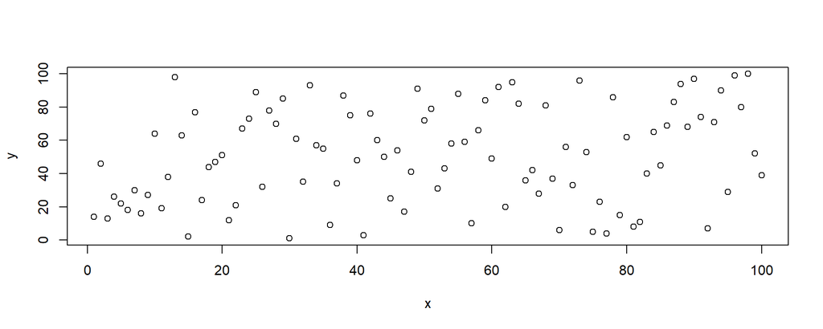

```r
x <- sample(1:100, 100)
y <- sample(1:100, 100)
plot(x, y)
```

## Demonstration: `plot()` with `abline`

When there is a relationship between two numeric variables, it is useful to add a “line of best fit” (a regression line). We will return to this concept in the lecture on predictive analytics!

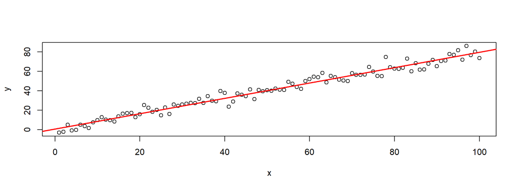

```r
x <- sample(1:100, 100)
y <- x * 0.8 + rnorm(100, mean = 0, sd = 5)
plot(x, y)
abline(lm(y ~ x), col = "red", lwd = 2)
```

## Demonstration: `plot()` factor data

If a factor variable is supplied, a bar plot showing counts of each factor level is produced (a univariate graph of a categorical variable). The height of each bar is equal to the counts of each level.

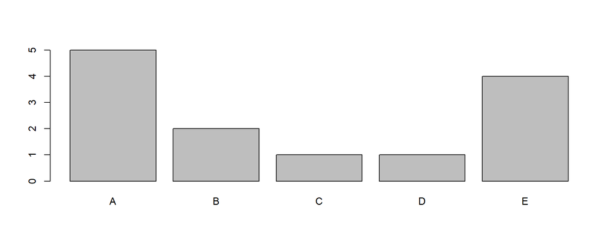

```r
f <- factor(c("A", "B", "E", "A", "E", "C", "B", "E", "A", "A", "A", "D", "E"))
plot(f)
```

## Plot options

The list of graphical to control base `R` plots is listed below. Base `R` plots include `plot()`, `hist()`, `pie()`, etc. It is important to reiterate that these options do not apply to non-base graphics packages, such as `ggplot2`, `plotly`, `lattice`.

The list is extensive, there are **over 70** in total ranging from layout and margins to font styles, axis behaviour, and clipping control… should you learn and memorise all of them?

Layout & Margins

- `mfrow`, `mfcol`: Multi-plot layout (rows vs. columns)
- `mar`: Margins (`c(bottom, left, top, right)`)
- `oma`: Outer margins
- `mai`, `omi`: Margins in inches

Axes & Ticks

- `xaxs`, `yaxs`: Axis style (“r”, “i”, “s”, “e”, “d”)
- `xaxt`, `yaxt`: Axis rendering (“n” to suppress)
- `xlog`, `ylog`: Log scale axes
- `las`: Label orientation (0–3)
- `tck`: Tick length
- `mgp`: Axis title, labels, tick positions

Colours & Lines

- `col`, `col.axis`, `col.lab`, `col.main`, `col.sub`: Element colors
- `lty`: Line type (1–6 or custom)
- `lwd`: Line width
- `bg`, `fg`: Background and foreground colors

Text & Fonts

- `cex`, `cex.axis`, `cex.lab`, `cex.main`, `cex.sub`: Text size
- `font`, `font.axis`, `font.lab`, `font.main`, `font.sub`: Font style
- `ps`: Point size
- `family`: Font family

Plot Elements

- `pch`: Point character
- `type`: Plot type (“p”, “l”, “b”, etc.)
- `bty`: Box type (“o”, “n”, “l”, etc.)
- `xpd`: Clipping behavior

Coordinate System

- `usr`: User coordinate limits
- `pin`: Plot dimensions in inches
- `plt`: Plot region as fraction of figure region

Titles & Labels

- `main`, `sub`: Main and subtitle text
- `xlab`, `ylab`: Axis labels

Miscellaneous

- `new`: Start new plot
- `ask`: Pause between plots
- `page`: Clear screen before plotting
- `cin`, `cra`, `cxy`: Character size metrics (read-only)

## Controlling plot appearance

There is no need to memorise the 70+ parameters that control base `R` plots, but it is important to understand how they work.

For example `par(mfrow = c(2, 2))` will set the plot window to be a 2 by 2 grid (allowing 4 plots to appear within a single plot window). Understanding this example can save you a lot time investigating other unnecessarily complex plot control options.

Being able to adjust settings you use regularly “by hand” is incredibly useful even if it seems tedious on first glance. You will need to know how to adjust code written by others, how to adopt your own code to new contexts either within of between documents and projects, and of course to edit and quality check code generated by AI.

## Using AI to control plots

“Designing” data visualisations with AI requires using natural language prompts that express your *design intentions*. Good prompts will be specific with their intention. The quality of your prompts will in part depend on your own understanding of the data structure (i.e., the insights obtained at the start of your project using functions `head()`, `str()`, etc.)

For adjusting individual plot options, it remains useful to know how to do this “by hand” although there is no harm done in asking AI something like *“use solid triangles for automatic and hollow circles for manuals”* instead of remembering that `pch = 18` is a solid triangle and `pch = 1` is a hollow circle!

## Demonstration: Using AI

Consider the following prompt: *“Use plot() in R with the mtcars dataset to visualise mpg (miles per gallon) and wt (weight), with points colour-coded according to cyl (number of cylinders). Add a regression line, use a transparent background, suppress the plot box, and include a title with mathematical notation. Add a legend for cylinder categories.”*.

This generates the following code and plot below:

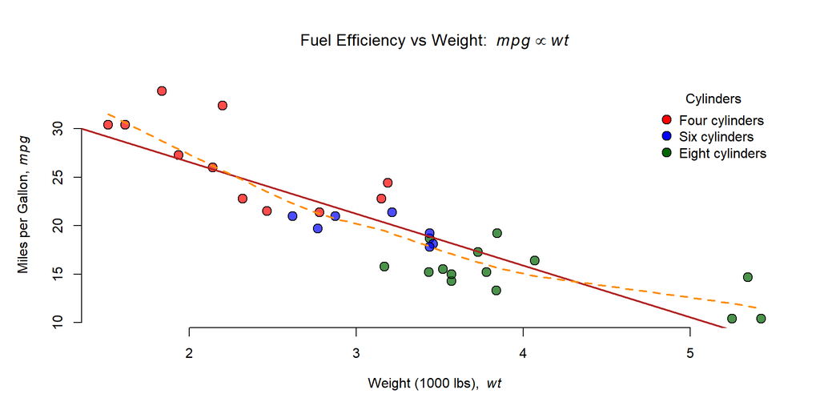

```r
## AI-GENERATED CODE ##
par(bg = "transparent", mar = c(5, 5, 5, 2))

# Prepare data
data <- mtcars
cyl_factors <- factor(data$cyl)
colors <- c("red", "blue", "darkgreen")
col_map <- adjustcolor(colors[as.numeric(cyl_factors)], alpha.f = 0.7)

# Scatterplot with styled points
plot(data$wt, data$mpg,
     pch = 21, bg = col_map, col = "black",
     cex = 1.5,
     xlab = expression("Weight (1000 lbs), " ~ italic(wt)),
     ylab = expression("Miles per Gallon, " ~ italic(mpg)),
     main = expression("Fuel Efficiency vs Weight: " ~ italic(mpg) %prop% italic(wt)),
     bty = "n")

# Add regression line (linear)
model <- lm(mpg ~ wt, data = data)
abline(model, col = "firebrick", lwd = 2, lty = 1)

# Add smooth loess curve
lines(lowess(data$wt, data$mpg), col = "darkorange", lwd = 2, lty = 2)

# Add legend with background
legend("topright",
       legend = levels(cyl_factors),
       title = "Cylinders",
       pt.bg = colors,
       pch = 21,
       pt.cex = 1.5,
       bty = "n",
       box.lwd = 0,
       inset = 0.02)
```

## Types of data visualisation

Different types of data visualisations exist because they each serve unique purposes and are suited to different kinds of data and analysis needs.

Some are better suited for categorical data (e.g., bar charts), while others are ideal for continuous data (e.g., histograms). Visualisations which show two or more variables together can be used to aid an analyst in inferring whether there is a functional relationship among those variables.

## Bar plots

A bar plot displays the distribution (frequency) of a categorical variable through vertical or horizontal bars. The base `barplot()` function treats uses the input data to determine the height of each bar.

If the input data is a vector, the values determine the heights of the bars in the plot and a vertical bar plot is produced.

## Demonstration: `barplot()`

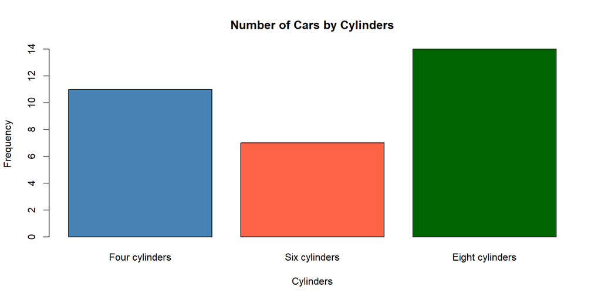

```r
table(mtcars$cyl) |> barplot(main = "Number of Cars by Cylinders",
        xlab = "Cylinders",
        ylab = "Frequency",
        col  = c("steelblue", "tomato", "darkgreen"))
```

## Visualising a contingency table

If height is a matrix or table rather than a vector, the resulting graph will be a stacked or grouped bar plot.

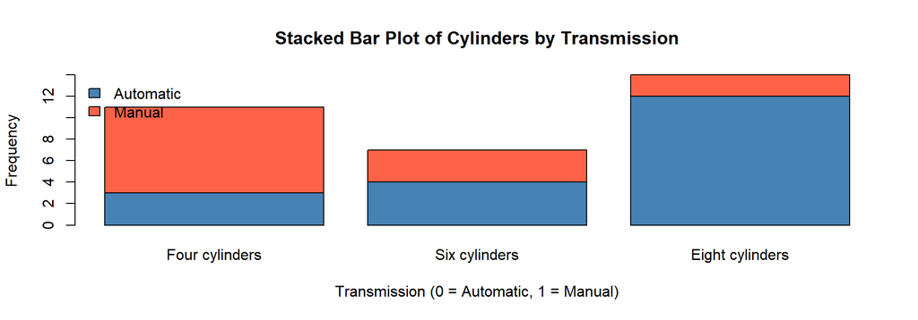

```r
counts <- table(mtcars$am, mtcars$cyl)

barplot(counts,
        main = "Stacked Bar Plot of Cylinders by Transmission",
        xlab = "Transmission (0 = Automatic, 1 = Manual)",
        ylab = "Frequency",
        col  = c("steelblue", "tomato", "darkgreen"))
legend("topleft", legend = rownames(counts),
       fill = c("steelblue","tomato","darkgreen"), bty = "n")
```

## Histograms

Histograms display the distribution of a continuous variable. The observations on the continuous variable are grouped into a specified number of “bins”.

The `x`-axis displays the bins and `y`-axis displays the frequency of observations in each bin. The base `hist()` function will plot a histogram from a numeric vector of values.

## Demonstration: `hist()`

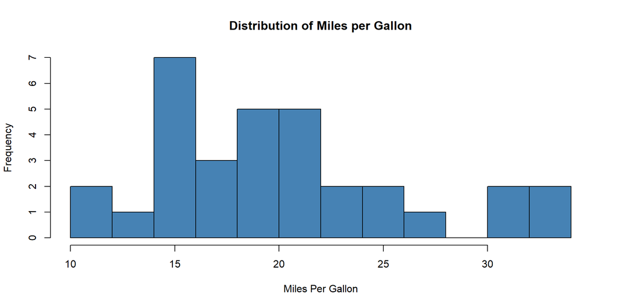

```r
hist(mtcars$mpg,
     breaks=12,
     xlab="Miles Per Gallon",
     main="Distribution of Miles per Gallon",
     col = "steelblue")
```

## Boxplots

A boxplot is useful for visualising how the distribution of a continuous variable differs across the categories of a grouping variable. This is expressed using a formula within the plot command, i.e., `mpg ~ factor(cyl)`

## Demonstration: `boxplot()`

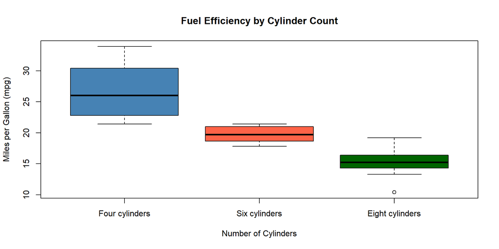

```r
boxplot(mpg ~ factor(cyl),
        data = mtcars,
        main = "Fuel Efficiency by Cylinder Count",
        xlab = "Number of Cylinders",
        ylab = "Miles per Gallon (mpg)",
        col  = c("steelblue", "tomato", "darkgreen"))
```

## Scatterplots

Scatter plots describe the relationship between two continuous variables (the graphical equivalent of a correlation analysis). The basic function for creating a scatterplot in `R` is `plot()`, using the syntax `plot(x, y)` where x and y are two numeric vectors.

We saw this plot at the very start, but the example shown the number data points was limited (only 100, for demonstrative purposes).

Scatterplots become difficult to interpret when there is significant overlap among the data points, of worse, cannot be drawn when there many observations, *say as many more than as 10,000…* data points to plot.

## Demonstration: `plot()`

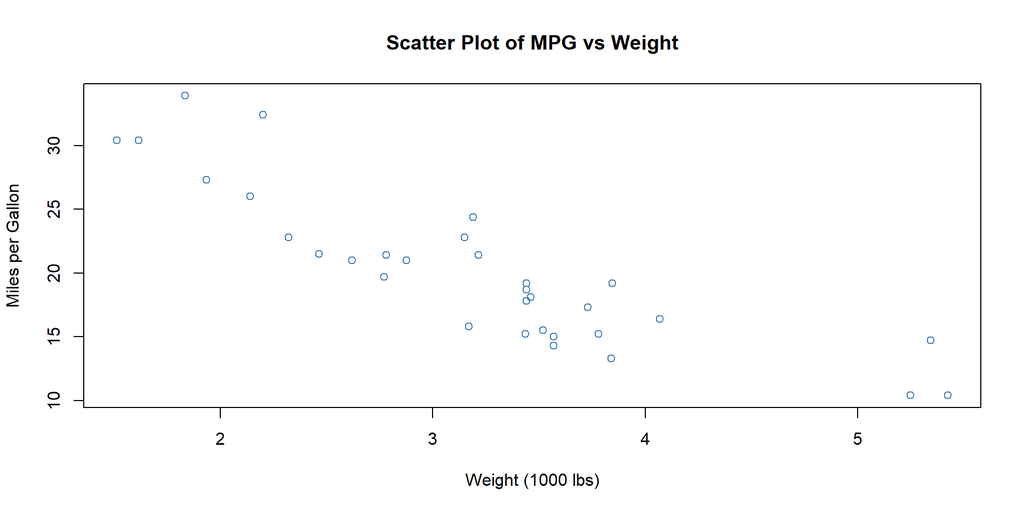

```r
plot(mtcars$wt, mtcars$mpg,
     main = "Scatter Plot of MPG vs Weight",
     xlab = "Weight (1000 lbs)",
     ylab = "Miles per Gallon",
     col  = "steelblue")
```

## Plotting large amounts of data

If a data frame contains many more observations, for example as many as *10,000* or more then a basic scatter plot will not render well. Consider the example below which plots 10,000 randomly distributed data points.

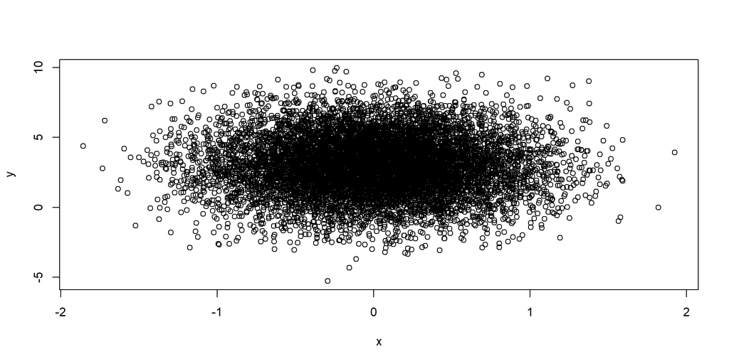

```r
x <- rnorm(10000, mean=0, sd=.5)
y <- rnorm(10000, mean=3, sd=2)
plot(x, y)
```

## Demonstration: `smoothScatter()`

The `smoothScatter()` plot is a good base `R` alternative to `plot()` for situations when you have a large number of overlapping points. Instead of plotting every point, it reveal structure with a colour coded heat map.

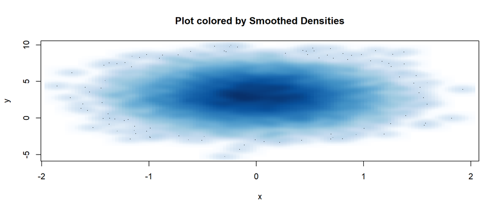

```r
smoothScatter(x, y, main="Plot colored by Smoothed Densities")
```

Thank you!

[figure not shown]